# Tarea-09-Eliminación-gaussiana-vs-Gauss-Jordan-PintoJuanFrancisco

### ESCUELA POLITÉCNICA NACIONAL

### FACULTAD DE INGENIERÍA EN SISTEMAS

### METODOS NUMERICOS ICCD412

*JUAN FRANCISCO PINTO ANDRANGO*

*Tarea 9 Eliminación Gaussina vs Gauss Jordan*

*GR1CC*

*FECHA DE ENTREGA 7 de ENERO DEL 2026*

### Conjunto de Ejericios

1. Para cada uno de los siguientes sistemas lineales, obtenga, de ser posible, una solución con métodos gráficos.Explique los resultados desde un punto de vista geométrico

```python
import numpy as np
import matplotlib.pyplot as plt

def resolver_grafico_2inc(eqs, xlim=(-10, 10), num=400, tol=1e-8):


    eqs = np.array(eqs, dtype=float)
    n = len(eqs)

    if n < 2:
        raise ValueError("Se necesitan al menos 2 ecuaciones.")

    x1 = np.linspace(xlim[0], xlim[1], num)
    intersecciones = []

    plt.figure(figsize=(7,5))

    # Graficar la ecuciones
    for i, (a, b, c) in enumerate(eqs, start=1):
        if abs(b) > tol:
            x2 = (c - a*x1) / b
            plt.plot(x1, x2, label=f"E{i}")
        else:
            if abs(a) > tol:
                plt.axvline(c/a, label=f"E{i}")

    # ver las intersecciones
    for i in range(n):
        a1, b1, c1 = eqs[i]
        for j in range(i+1, n):
            a2, b2, c2 = eqs[j]
            A = np.array([[a1, b1],
                          [a2, b2]])
            if abs(np.linalg.det(A)) > tol:
                p = np.linalg.solve(A, [c1, c2])
                intersecciones.append(p)

    intersecciones = np.array(intersecciones)


    if len(intersecciones) > 0:
        puntos_comunes = []
        for p in intersecciones:
            if all(abs(a*p[0] + b*p[1] - c) < tol for a,b,c in eqs):
                puntos_comunes.append(p)

        puntos_comunes = np.array(puntos_comunes)

        if len(puntos_comunes) > 0:
            plt.scatter(puntos_comunes[:,0], puntos_comunes[:,1], s=80)
        else:
            plt.scatter(intersecciones[:,0], intersecciones[:,1], s=50)

    plt.axhline(0)
    plt.axvline(0)
    plt.xlabel("$x_1$")
    plt.ylabel("$x_2$")
    plt.grid(True)
    plt.legend()
    plt.show()
```

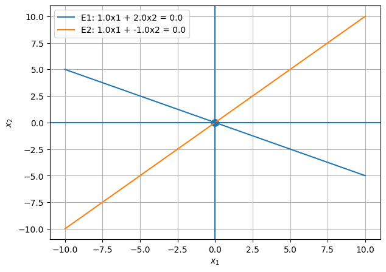

```python
eqs = [
    (1,  2, 0),
    (1, -1, 0)
]
resolver_grafico(eqs)
```

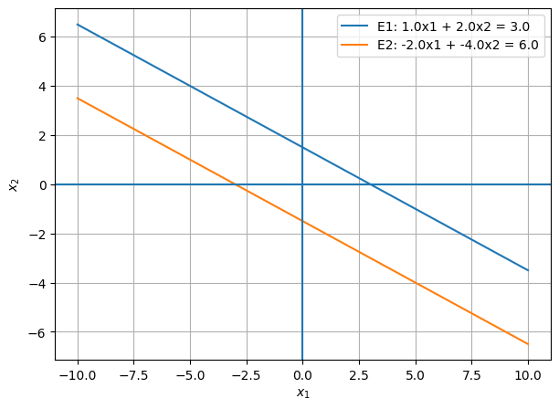

```python
eqs = [
    (1,  2, 3),
    (-2, -4, 6)
]
resolver_grafico(eqs)
```

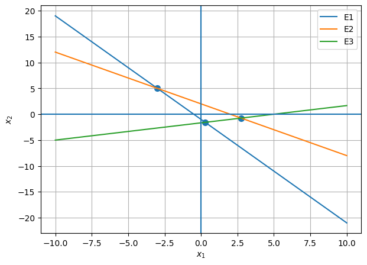

```python
eqs = [
    (2,  1, -1),
    (1, 1, 2),
    (1, -3, 5)
]
resolver_grafico_2inc(eqs)
```

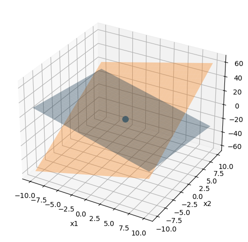

```python
eqs = [
    (2, 1,  1,  1),   # 2x1 + x2 + x3 = 1
    (2, 4, -1, -1)    # 2x1 + 4x2 - x3 = -1
]
resolver_grafico(eqs)
```

### 2 Eliminación Gaussiana

Utilice la eliminación gaussiana con sustitución hacia atrás

y aritmética de redondeo de dos dígitos para resolver

los siguientes sistemas lineales.

No reordene las ecuaciones.

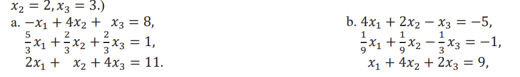

```python
def gaussian_elimination(A, b):
    n = len(b)
    A = np.hstack((A, b.reshape(-1, 1)))  # Matriz aumentada

    # Eliminación hacia adelante (sin redondeo en factor)
    for i in range(n):
        for j in range(i + 1, n):
            factor = A[j, i] / A[i, i]
            A[j, i:] -= factor * A[i, i:]

    # Sustitución hacia atrás con redondeo final
    x = np.zeros(n)
    for i in range(n - 1, -1, -1):
        x[i] = (A[i, -1] - np.dot(A[i, i + 1:n], x[i + 1:])) / A[i, i]

    return np.round(x, 2)  # Redondeo aquí

def main():
    # Sistema a
    A_a = np.array([
        [-1, 4, 1],
        [5/3, 2/3, 2/3],
        [2, 1, 4]
    ])
    b_a = np.array([8, 1, 11])

    solution_a = gaussian_elimination(A_a, b_a)
    print("Solución del sistema a:", solution_a)

    # Sistema b
    A_b = np.array([
        [4, 2, -1],
        [1/9, 1/9, -1/3],
        [1, 4, 2]
    ])
    b_b = np.array([-5, -1, 9])

    solution_b = gaussian_elimination(A_b, b_b)
    print("Solución del sistema b:", solution_b)

if __name__ == "__main__":
    main()
```

```
Solución del sistema a: [-1.  1.  3.]
Solución del sistema b: [-1.  1.  3.]
```

### 3 Eliminacion Gaussiana

utilice la eliminacion gaussiana con sustitucion hacia atras y artimetica de redondeo de dos digitos

```python
import numpy as np

def eliminacion_gaussiana(A, b, tol=1e-12, pivoteo=True):

    A = np.array(A, dtype=float)
    b = np.array(b, dtype=float).reshape(-1)

    n = A.shape[0]
    if A.shape != (n, n):
        raise ValueError("A debe ser cuadrada (n x n).")
    if b.shape[0] != n:
        raise ValueError("b debe tener longitud n.")

    # Matriz aumentada [A | b]

    Ab = np.hstack([A, b.reshape(-1, 1)])

    # Eliminación hacia adelante

    for i in range(n):
        if pivoteo:
            # Buscar el mayor pivote en columna i desde fila i
            fila_max = i + np.argmax(np.abs(Ab[i:, i]))
            if abs(Ab[fila_max, i]) < tol:
                continue

            # Intercambiar filas
            if fila_max != i:
                Ab[[i, fila_max]] = Ab[[fila_max, i]]

        # Si el pivote es ~0, no se puede eliminar en esta columna
        piv = Ab[i, i]
        if abs(piv) < tol:
            continue

        for j in range(i + 1, n):
            factor = Ab[j, i] / piv
            Ab[j, i:] -= factor * Ab[i, i:]

    U = Ab[:, :n]
    c = Ab[:, n]


    rango_A = np.linalg.matrix_rank(A, tol=tol)
    rango_Ab = np.linalg.matrix_rank(Ab[:, :], tol=tol)

    if rango_Ab > rango_A:
        return {"estado": "sin_solucion", "x": None, "U": U, "Ab": Ab}
    if rango_A < n:
        return {"estado": "infinitas", "x": None, "U": U, "Ab": Ab}

    # Sustitucion hacia atras
    x = np.zeros(n)
    for i in range(n - 1, -1, -1):
        if abs(U[i, i]) < tol:

            return {"estado": "infinitas", "x": None, "U": U, "Ab": Ab}

        suma = np.dot(U[i, i+1:], x[i+1:])
        x[i] = (c[i] - suma) / U[i, i]

    return {"estado": "unica", "x": x, "U": U, "Ab": Ab}
```

```python
# Primer Ejercicio
A = [
    [1,  1, 3],
    [3,  -3,  1],
    [1, 1,  0]
]
b = [2, -1, 3]

res = eliminacion_gaussiana(A, b)

if res["estado"] == "unica":
    print("Solución:", res["x"])
else:
    print("Estado:", res["estado"])
```

```
Solución: [ 1.38888889  1.61111111 -0.33333333]
```

```python
# Segundo Ejercicio
A = [
    [2,  -1.5, 3],
    [-1,  0,  2],
    [4, -4.5,  5]
]
b = [1, 3, 1]

res = eliminacion_gaussiana(A, b)

if res["estado"] == "unica":
    print("Solución:", res["x"])
else:
    print("Estado:", res["estado"])
```

```
Solución: [-1. -0.  1.]
```

```python
A4 = [
    [2,  0,  0,  0],
    [1, 1.5,  0,  0],
    [0,  -3, 0.5,  0],
    [2,  -2,  1, 1]
]
b4 = [3, 4.5, -6.6, 0.8]

res4 = eliminacion_gaussiana(A4, b4)

if res4["estado"] == "unica":
    print("Solución 4x4:", res4["x"])
else:
    print("Estado:", res4["estado"])
```

```
Solución 4x4: [ 1.5  2.  -1.2  3. ]
```

```python
A4 = [
    [1,  1,  0,  1],
    [2, 1,  -1,  3],
    [4,  -1, -2,  2],
    [3,  -1,  -1, 2]
]
b4 = [2, 1, 0, -3]

res4 = eliminacion_gaussiana(A4, b4)

if res4["estado"] == "unica":
    print("Solución 4x4:", res4["x"])
else:
    print("Estado:", res4["estado"])
```

```
Solución 4x4: [ 0.66666667  3.33333333 -2.33333333 -2.        ]
```

### 4 Eliminacion Gausiana y Aritmetica computacional

para resolver los siguientes sistemas lineales

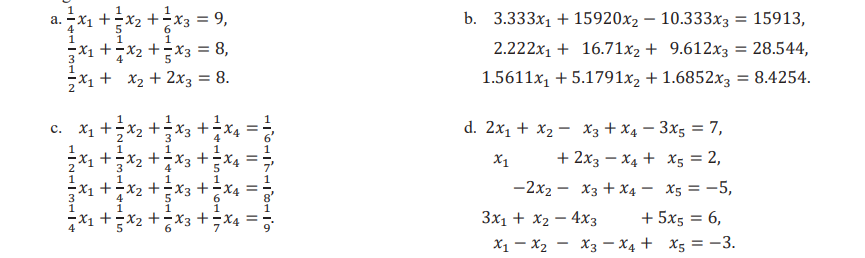

```python
def gaussian_elimination(matrix, vector):
    A = np.array(matrix, dtype=np.float64)
    b = np.array(vector, dtype=np.float64)

    n = len(b)

    # Eliminación hacia adelante con pivoteo parcial
    for i in range(n):
        max_row = np.argmax(np.abs(A[i:, i])) + i
        if i != max_row:
            A[[i, max_row]] = A[[max_row, i]]
            b[[i, max_row]] = b[[max_row, i]]

        pivot = A[i, i]
        if np.isclose(pivot, 0):
            raise ValueError("Sistema singular o sin solución única.")

        for j in range(i + 1, n):
            factor = A[j, i] / pivot
            A[j, i:] -= factor * A[i, i:]
            b[j] -= factor * b[i]

    # Sustitución hacia atrás
    x = np.zeros(n)
    for i in range(n - 1, -1, -1):
        x[i] = (b[i] - np.dot(A[i, i + 1:], x[i + 1:])) / A[i, i]

    return np.round(x, 6)  # Ajusta la precisión final si lo deseas


# Ejemplo de sistemas de la imagen
systems = [
    {"matrix": [[1/4, 1/5, 1/6], [1/3, 1/4, 1/5], [1/2, 1, 2]], "vector": [9, 8, 8]},
    {"matrix": [[3.333, 15920, -10.333], [2.222, 16.71, 9.612], [1.5611, 5.1791, 1.6852]], "vector": [15913, 28.544, 8.4254]},
    {"matrix": [[1, 1/2, 1/3, 1/4], [1/2, 1/3, 1/4, 1/5], [1/3, 1/4, 1/5, 1/6], [1/4, 1/5, 1/6, 1/7]], "vector": [1/5, 1/6, 1/7, 1/9]},
    {"matrix": [[2, 1, -1, -3, -3], [1, 0, 2, -1, -4], [-2, 0, -3, 4, -5], [3, 1, 2, -4, 5], [1, -1, -3, -4, -1]], "vector": [7, 2, -5, 6, -3]}
]

# Resolver cada sistema
for idx, system in enumerate(systems):
    print(f"\nSistema {chr(97 + idx)}:")
    try:
        solution = gaussian_elimination(system["matrix"], system["vector"])
        print("Solución:", solution)
    except ValueError as e:
        print(e)
```

```
Sistema a:
Solución: [-227.076923  476.923077 -177.692308]

Sistema b:
Solución: [1. 1. 1.]

Sistema c:
Solución: [  1.930159 -23.047619  57.047619 -36.888889]

Sistema d:
Solución: [-5.538462  7.846154  1.307692 -3.487179 -0.358974]
```

### 5 Sistema Lineal

dado el sistema lineal

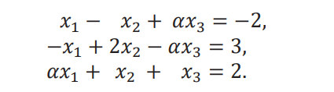

a) encuentre el valores de α para los que el sistema no tiene soluciones

b) encuentre el valores de α para los que el sistema tiene un numero infinito de soluciones

c) suponga que existe una unica solucion para una determinada, encuentre la solucion

```python
def analyze_system(alpha):
    # Construye matriz del sistema en función de α
    A = np.array([
        [1, -1, alpha],
        [-1, 2, -alpha],
        [alpha, 1, 1]
    ], dtype=np.float64)
    b = np.array([-2, 3, 2], dtype=np.float64)

    # Determinante para saber si tiene solución única
    det = np.linalg.det(A)

    if np.isclose(det, 0):
        # Verificamos los rangos
        augmented = np.column_stack((A, b))
        rank_A = np.linalg.matrix_rank(A)
        rank_aug = np.linalg.matrix_rank(augmented)

        if rank_A == rank_aug:
            return "Infinitas soluciones"
        else:
            return "No tiene solución"
    else:
        # Solución única
        x = np.linalg.solve(A, b)
        return np.round(x, 4)

# Análisis para varios valores de α
alphas_to_test = [0, -1, -2, 1, 2, 3]
for alpha in alphas_to_test:
    result = analyze_system(alpha)
    print(f"Para α = {alpha}, el resultado es: {result}")
```

```
Para α = 0, el resultado es: [-1.  1.  1.]
Para α = -1, el resultado es: Infinitas soluciones
Para α = -2, el resultado es: [-0.3333  1.      0.3333]
Para α = 1, el resultado es: No tiene solución
Para α = 2, el resultado es: [ 1.  1. -1.]
Para α = 3, el resultado es: [ 0.5  1.  -0.5]
```

```python
def analizar_sistema(a):
    # Matriz de coeficientes
    A = np.array([
        [1, -1, a],
        [-1, 2, -a],
        [a, 1, 1]
    ], dtype=float)

    # Vector independiente
    b = np.array([-2, 3, 2], dtype=float)

    # Determinante
    det_A = np.linalg.det(A)

    if np.isclose(det_A, 0):
        # Verificamos los rangos
        rA = np.linalg.matrix_rank(A)
        Ab = np.column_stack((A, b))
        rAb = np.linalg.matrix_rank(Ab)

        if rA == rAb:
            return f"Para a = {a:.2f}: Infinitas soluciones"
        else:
            return f"Para a = {a:.2f}: No tiene solución"
    else:
        # Solución única
        x = np.linalg.solve(A, b)
        return f"Para a = {a:.2f}: Solución única → x = {np.round(x, 3)}"

# Probar varios valores de a
valores_a = [-2, -1, 0, 0.5, 1, 2]
for a in valores_a:
    print(analizar_sistema(a))
```

```
Para a = -2.00: Solución única → x = [-0.333  1.     0.333]
Para a = -1.00: Infinitas soluciones
Para a = 0.00: Solución única → x = [-1.  1.  1.]
Para a = 0.50: Solución única → x = [-2.  1.  2.]
Para a = 1.00: No tiene solución
Para a = 2.00: Solución única → x = [ 1.  1. -1.]
```

### 6 Ejercicio aplicados

Suponga que en un sistema biológico existen n especies de animales y m fuentes de alimento. Si $x_j$ representa la población de las j-ésimas especies, para cada 𝑗 = 1, ⋯ , 𝑛; $b_i$; representa el suministro diario disponible del i-ésimo alimento y $a_{ij}$ representa la cantidad del i-ésimo alimento.

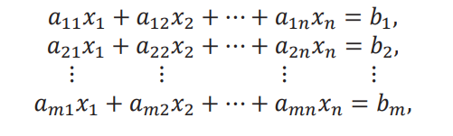

representa un equilibrio donde existe un suministro diario de alimento para cumplir con precisión con el promedio diario de consumo de cada especie.

#### a SI

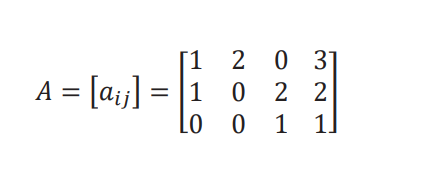

$x=(x_j)=[1000,500,350,400],$ y $b=(b_i)=[3500,2700,900].$ ¿Existe suficiente alimento para satisfacer el consumo promedio diario?

```python
from scipy.optimize import linprog

def is_food_sufficient(A, x, b):
    consumption = np.dot(A, x)
    return np.all(consumption <= b), consumption

A_food = np.array([
    [1, 2, 0, 3],
    [1, 0, 2, 2],
    [0, 0, 1, 1]
], dtype=float)

x_food = np.array([1000, 500, 350, 400], dtype=float)
b_food = np.array([3500, 2700, 900], dtype=float)

sufficient, consumption = is_food_sufficient(A_food, x_food, b_food)
print("¿Hay suficiente alimento para satisfacer el consumo promedio diario?", sufficient)
print("Consumo calculado:", consumption)
print("Suministro disponible:", b_food)
```

```
¿Hay suficiente alimento para satisfacer el consumo promedio diario? True
Consumo calculado: [3200. 2500.  750.]
Suministro disponible: [3500. 2700.  900.]
```

### preguntas

*b ¿Cuál es el número máximo de animales de cada especie que se podría agregar de forma individual al sistema con el suministro de alimento que cumpla con el consumo?*

*- c. Si la especie 1 se extingue, ¿qué cantidad de incremento individual de las especies restantes se podría soportar?*

*d. Si la especie 2 se extingue, ¿qué cantidad de incremento individual de las especies restantes se podría soportar?*

```python
def calcular_incrementos_individuales(A, x, b):
    A = np.array(A, dtype=float)
    x = np.array(x, dtype=float)
    b = np.array(b, dtype=float)

    incrementos = []
    consumo_actual = A @ x
    disponible = b - consumo_actual

    for j in range(len(x)):
        a_col = A[:, j]
        # Detectamos si alguna entrada de a_col es cero
        with np.errstate(divide='ignore', invalid='ignore'):
            delta = np.where(np.abs(a_col) > 1e-8, disponible / a_col, np.inf)

        # Solo consideramos los límites válidos
        delta_valido = delta[np.isfinite(delta)]
        if len(delta_valido) > 0:
            incremento_max = np.floor(np.min(delta_valido))
        else:
            incremento_max = 0  # No se puede agregar esa especie

        incrementos.append(int(incremento_max))

    return incrementos

# Datos originales
A = [
    [1, 2, 0, 3],
    [1, 0, 2, 2],
    [0, 0, 1, 1]
]
x = [1000, 500, 350, 400]
b = [3500, 2700, 900]

# Literal b
print("🔹 Incrementos individuales permitidos:")
print(calcular_incrementos_individuales(A, x, b))

# Literal c: especie 1 extinta
A_c = [row[1:] for row in A]  # quitar primera columna
x_c = x[1:]
b_c = np.array(b) - np.array([row[0] for row in A]) * x[0]

print("🔹 Incrementos si especie 1 se extingue:")
print(calcular_incrementos_individuales(A_c, x_c, b_c))

# Literal d: especie 2 extinta
A_d = [row[:1] + row[2:] for row in A]  # quitar segunda columna
x_d = [x[0]] + x[2:]
b_d = np.array(b) - np.array([row[1] for row in A]) * x[1]

print("🔹 Incrementos si especie 2 se extingue:")
print(calcular_incrementos_individuales(A_d, x_d, b_d))
```

```
🔹 Incrementos individuales permitidos:
[200, 150, 100, 100]
🔹 Incrementos si especie 1 se extingue:
[150, 100, 100]
🔹 Incrementos si especie 2 se extingue:
[200, 100, 100]
```

### 7 Ejercicios teoricos

```python
def gauss_jordan(A, b):
    """
    Resuelve un sistema de ecuaciones lineales Ax = b usando el método Gauss-Jordan.
    """
    A = A.astype(np.float32)
    b = b.astype(np.float32)
    n = len(b)

    # Formar la matriz aumentada
    aug_matrix = np.hstack((A, b.reshape(-1, 1)))

    for i in range(n):
        # Hacer el pivote igual a 1 dividiendo toda la fila
        aug_matrix[i] = aug_matrix[i] / aug_matrix[i, i]

        # Hacer ceros en la columna del pivote para las demás filas
        for j in range(n):
            if i != j:
                aug_matrix[j] -= aug_matrix[j, i] * aug_matrix[i]

    # Extraer la solución
    x = aug_matrix[:, -1]
    return x

# Sistemas de ecuaciones del ejercicio
# Sistema (a)
A_a = np.array([
    [1/4, 1/5, 1/6],
    [1/3, 1/4, 1/5],
    [1/2, 1, 1]
], dtype=np.float32)
b_a = np.array([9, 8, 8], dtype=np.float32)

# Sistema (b)
A_b = np.array([
    [3.333, 15920, 10.333],
    [2.222, 16.71, 9.612],
    [1.5611, 5.1791, 1.6852]
], dtype=np.float32)
b_b = np.array([15913, 28.544, 8.4254], dtype=np.float32)

# Sistema (c)
A_c = np.array([
    [1, 1/2, 1/3, 1/4],
    [1/2, 1/3, 1/4, 1/5],
    [1/3, 1/4, 1/5, 1/6],
    [1/4, 1/5, 1/6, 1/7]
], dtype=np.float32)
b_c = np.array([1/6, 1/7, 1/8, 1/9], dtype=np.float32)

# Sistema (d)
A_d = np.array([
    [2, 1, -1, 1, -3],
    [1, 2, -3, -4, 0],
    [-2, -2, -3, 4, -5],
    [3, 1, -2, -4, 5],
    [1, -1, -3, -4, 1]
], dtype=np.float32)
b_d = np.array([7, 2, -5, 6, -3], dtype=np.float32)

# Resolver cada sistema
x_a = gauss_jordan(A_a, b_a)
x_b = gauss_jordan(A_b, b_b)
x_c = gauss_jordan(A_c, b_c)
x_d = gauss_jordan(A_d, b_d)

# Mostrar resultados
print("Solución del sistema (a):", x_a)
print("Solución del sistema (b):", x_b)
print("Solución del sistema (c):", x_c)
print("Solución del sistema (d):", x_d)
```

```
Solución del sistema (a): [  306.00003 -1300.0002   1155.0002 ]
Solución del sistema (b): [1.0023832  0.99870026 1.0017889 ]
Solución del sistema (c): [-0.03174722  0.5952536  -2.380991    2.7778032 ]
Solución del sistema (d): [ 2.3945172   1.7342076  -0.06793801  1.0166866   0.20262219]
```

#### Link-Del-Repositorio-de-Git-Hub

https://github.com/JuanfranPinto/Metodos-Numericos-/blob/main/Tarea-09-Eliminaci%C3%B3n-gaussiana-vs-Gauss-Jordan-PintoJuanFrancisco.ipynb